[figure not shown]

Доклад по лабораторной работе №8

Шифр гаммирования

Скворцова Анастасия

2026-05-15

[figure not shown]

Содержание (i)

1. Цели и задачи

2. Выполнение лабораторной работы

3. Выводы

[figure not shown]

1. 1. Цели и задачи

1.1 Цель лабораторной работы

Освоить на практике применение режима однократного гаммирования на примере

кодирования различных исходных текстов одним ключом.

[figure not shown]

2. 2. Выполнение лабораторной

работы

2.1 Гаммирование

Гаммирование – это наложение (снятие) на открытые (зашифрованные) данные

криптографической гаммы, т.е. последовательности элементов данных, вырабатываемых с

помощью некоторого криптографического алгоритма, для получения зашифрованных

(открытых) данных.

2.2 Алгоритм взлома

Шифротексты обеих телеграмм можно получить по формулам режима однократного

гаммирования:

2.3 Алгоритм взлома

Открытый текст можно найти, зная шифротекст двух телеграмм, зашифрованных одним

ключом. Для это оба равенства складываются по модулю 2. Тогда с учётом свойства

операции XOR получаем:

2.4 Алгоритм взлома

Предположим, что одна из телеграмм является шаблоном — т.е. имеет текст

фиксированный формат, в который вписываются значения полей. Допустим, что

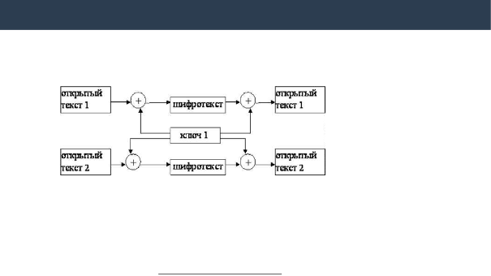

2.5 Схема работы алгоритма

Рисунок 1: Работа алгоритма гаммирования

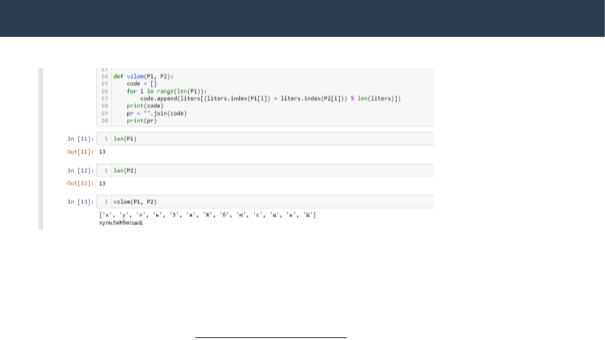

2.6 Пример работы программы

Рисунок 2: Работа алгоритма взлома ключа

[figure not shown]

3. 3. Выводы

3.1 Результаты выполнения лабораторной работы

В ходе выполнения лабораторной работы было разработано приложение, позволяющее

шифровать тексты в режиме однократного гаммирования.